# MSBMI 33200: Lecture 7

Anoop Mayampurath

November 18 2019

## Deep Learning

- Deep Learning is a branch of machine learning that attempts to learn representations of data that are increasingly meaningful.
- The notion of depth is simply the number of layers, each of gives a representation of the data.
- ANNs (or MLPs) have only one or two layers of representation, and hence are called “shallow” learners. Deep learning typically have tens or hundreds of successive layers of representation.

Consider the following deep learning architechture for recognizing digits.

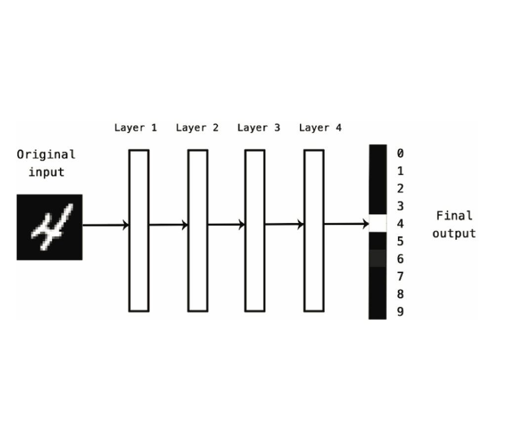

[Source: Deep Learning with Python Francois Chollet, Manning Publications]

Each layer learns representations that may look like:

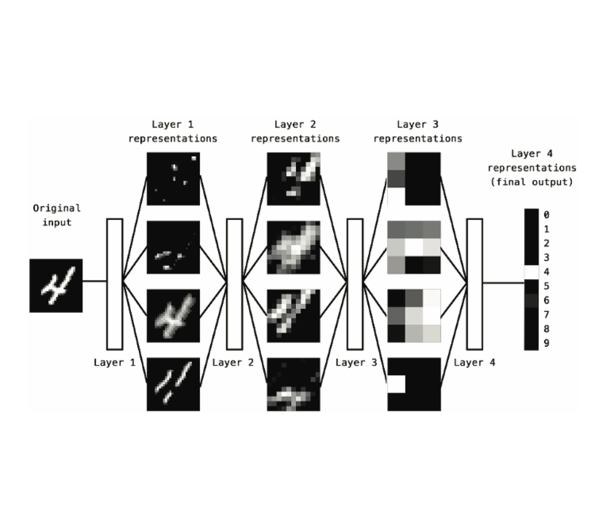

[Source: Deep Learning with Python Francois Chollet, Manning Publications]

Each layer is parameterized by a set of weights that are used to create representations of the data.

The final layer is used to create a prediction of the outcome. The predicted outcome is compared to the true outcome to derive a loss function.

The loss function is then used to update the weights.

This is different from successively joining a bunch of shallow learners, because  
1. it eliminates the need for feature engineering for large complex datasets.  
2. it learns all layers of represenation jointly and not in succession.

Deep learning became successful because of the congruence of three factors:

1. Better hardware: The early 2000s saw the rise of graphical processing units (GPUs) by companies like NVIDIA and AMD. GPUs were fast and capabale of massively parallel operations. Along with the hardward came programming frameworks called CUDA that researchers could use for neural network training.
2. Availability of large-scale labeled data such as the ImageNet (1.2 million images, 1000 categories of objects).

[figure not shown]

3. Better algorithms (SGD, RMSProp, Adam), activating functions (tanh, relu) and engineering tricks (batch processing, early stop)

## The result

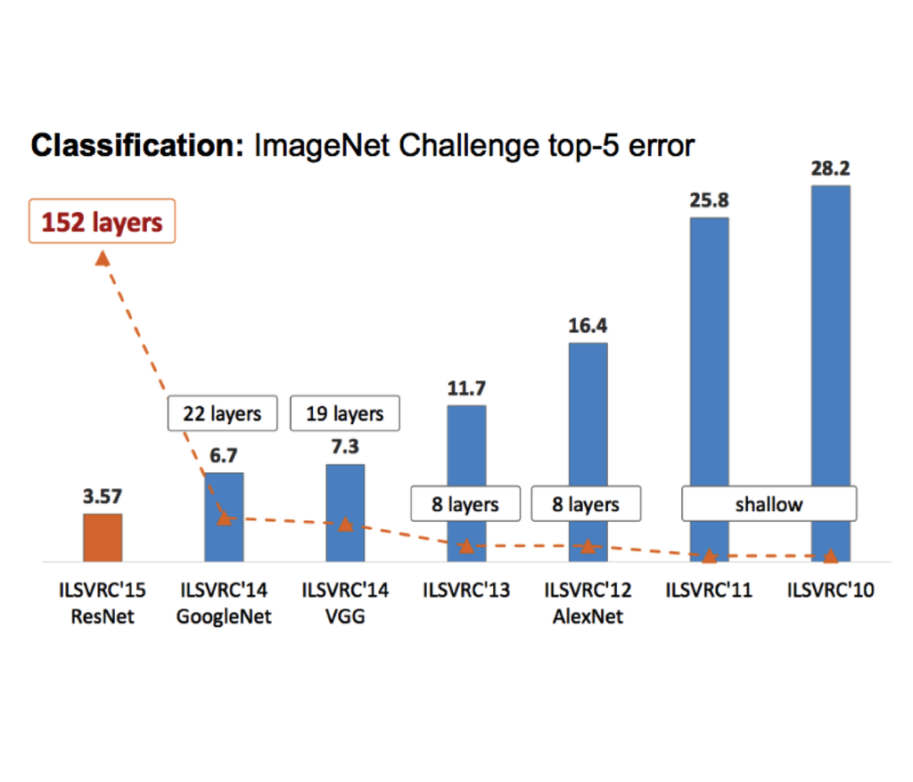

## Fundamentals:

Recall: In a classification model, the total loss function for all data points $i= 1 \dots n$ is called as log-loss and is written as:

$$J(w) = - \frac{1}{n} \sum_{i=1}^{n}[y_ilog(f(x_i, W)) + (1-y_i)log(1-f(x_i, W))]$$

where $f(x_i, W)$ is the predicted outcome and $y_i$ is the actual outcome.

Our objective is the find the $W$ that corresponds to the minimum $J(w)$

## Gradient Descent

The simplest approach to finding the minimum $J(w)$ is to choose a direction that minimizes $J(w)$ and keep following it. This is called as following the negative gradient. The algorithm is as follows:

- 1. Initialize $w$ with random values.
- 2. Calculate $J(w)$.
- 3. Choose the gradient that reduces $J(w)$ the most.
- 4. Update $w$ with:

$$w^{new} = w^{old} - \eta \frac{\partial J(w^{old})}{\partial w^{old}}$$

- 5. Repeat 2-4 until $w^{new} - w^{old} < \epsilon$ (called as convergence)

## Stochastic Gradient Descent

- This is a variant of the gradient descent that simply calculates the gradient at each update step for a single arbitarily chosen data point.
- SGD and other variants of GD are called as “optimizers”

## Backpropagation

Backpropagation takes the final loss value and moves backwards computing the gradients of outputs at every node using the chain rule.

## Activating functions

1. Sigmoid

$$h(z) = \frac {1}{1+e^{-z}}$$

2. Hyperbolic Tangent (or tanh)

$$h(z) = \frac {e^z-e^{-z}}{e^z+e^{-z}}$$

3. Rectified linear unit

$$h(z) = max(0, z)$$

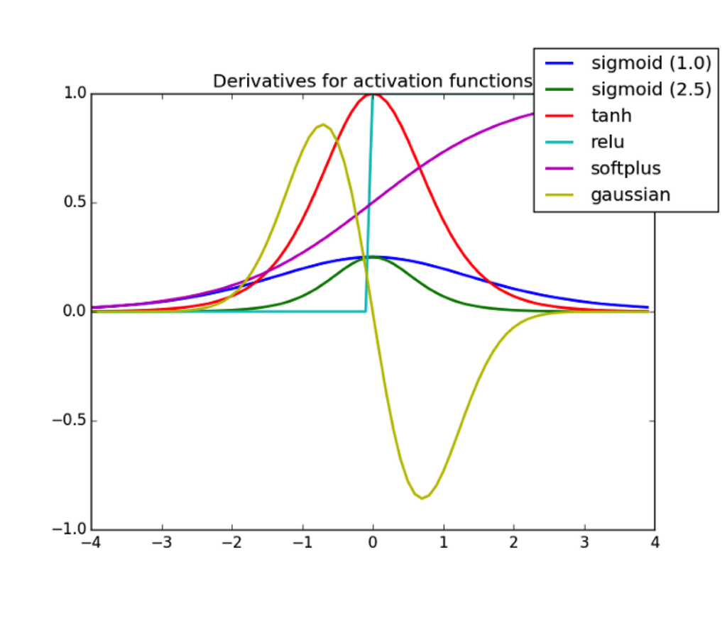

Source[https://towardsdatascience.com/activation-functions-neural-networks-1cbd9f8d91d6]

## Convolutional Neural Networks (CNNs)

CNNs have become the standard in image recognition. The two main operations involved in CNNs are

1. Convolution
2. Max-pooling

## Convolution operation

One of the drawbacks of a dense neural network layer is that there is no spatial information that is used in the learning.

In images, the arrangement of pixels is non-randomn. Thus, the spatial context of the predictors are important.

For example:

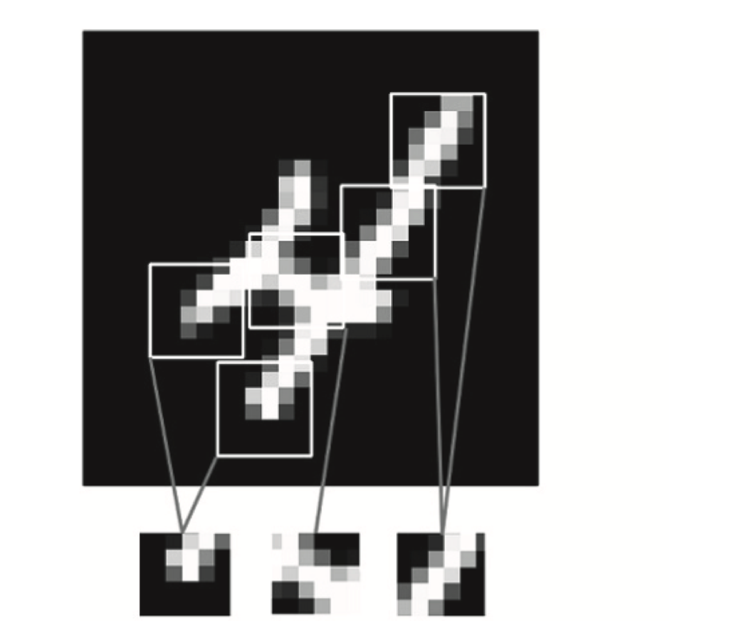

Groups of pixels make patterns. Some patterns can occur in multiple parts of the image making them recognizable anywhere.

Thus, we use a filter such as a 3x3 window to mark a region where we want a neuron to focus. Thus, the neuron only sees that part of the image.

We slide the window throughout the image, thereby defining connections from regions of the image to the neurons in the subsequent layer.

This has the effect of creating multiple filters (or neuron weights) that “learn” local features.

This operation is called convolution. The output of a convolutional layer is a feature map.

Doing this multiple times will lead to a network that learns local “low-level” features at first and then global “high-level” features at a later top layer

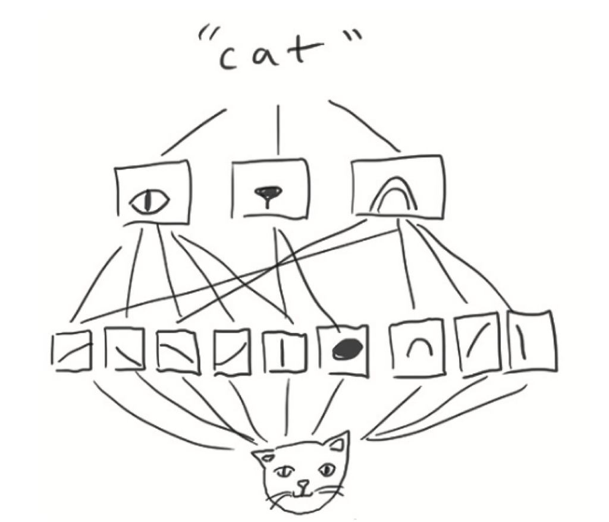

## Convolutional layer parameters

1. Filter size (e.g., 3x3)
2. Depth: number of channels, set to 3 for RGB, set to 1 for black/white images
3. Stride: the step size for filter.
4. Number of filters: Set to high-value, decrease with each successive layer
5. Padding: the amount of column and row pixels to pad so that convolutions are possible. This is (1,1) for 3x3 windows and (2,2) for 5x5 windows.

## Max pooling

Max pooling is the term given to the operation where we downsample a feature map before giving it as input to the next layer.

The downsampling works by taking the maximum pixel value within a filter window.

This forces the network to learn high-level features. It also reduces the number of parameters to train.

## Recurrent Neural Networks (RNN)

A characterestic of CNNs and MLPs is that each data point gets processed independently. However, for data formats such as time-series or text data where words are in sequence, it makes sense to capture the association between a single data point and its neighbors to acheive better prediction.

How do we do this? We retain information from training the past data points and update things with every data point.

The information retention is called as capturing a “state” of a neural network. Thus, the training of a NN for a data point depends on that data point and the state of the NN that has captured training up until that data point.

Thus, for an input $x_t$ at time $t$ (or sequence $t$), the output of the RNN is:

$$y_t = h(W*x_t + U*state_{t})$$

and the state gets updated to

$$state_{t+1} = y_t$$

where, $W$ and $U$ are parameters that we need to determine

The RNN should  
1. Be capable of handling variable length sequences.  
2. Be able to learn order AND long-term dependencies  
3. Use the same set of parameters throughout

We determine both $W$ and $U$ using backpropagation.

The backpropagation step involves taking the derivative of the gradient of the loss function with respect to the initial state ($state_0$) which is computed using the chain rule. However, because a number of $U$ matrix multiplications that are performed, we risk running into two problems

1. If the chain rule uses values that are too big, we have very large gradient values. too large to optimize. We can get over this by “clipping” the gradients if they are too large.
2. Conversely, if the chain rule uses values that are too small, we will have gradient values too small to matter. This is called the vanishing gradient problem.

## The Long-Short Term Memory (LSTM) unit

The LSTM is a “gated” cell or unit that controls what information gets passed to the next unit. The architechture is shown below.

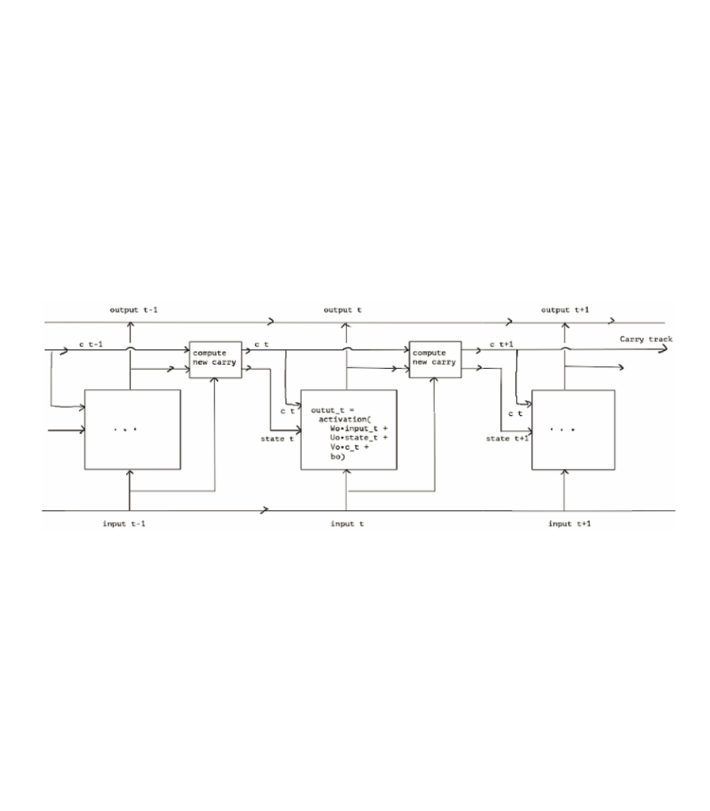

The main difference between an LSTM and an RNN is the addition of a carry term that gets combined with the data point and the previous state. Thus,

$$y_t = h(W*x_t + U*state_{t} + V*c_{t})$$

where

$$state_{t+1} = y_t$$

We compute $carry_{t+1}$ by the following formulae:

$$i_t = h(W_i*x_t + U_i*state_{t})$$
$$f_t = h(W_f*x_t + U_f*state_t)$$
$$k_t = h(W_k*x_t + U_k*state_t)$$

$$c_{t+1} = c_t * f_t + i_t * k_t$$

The activation function here is usually a sigmoid function, making $i_t, f_t, k_t$ betwen 0 and 1, thereby restricting the information flow between none (0) and all (1).

A basic way to think about this is as follows: the $f_t *c_t$ operation decides how much of the past information should be forgotten, while $i_t$ and $k_t$ controls what current information should be kept to carry forward.

However, all these are just a number of matrix multiplications of weights, inputs, and states designed to allow information from the beginning part of the sequence or time series to be carried forward and injected into the later units.